In a series of causal inference

# 📍 Đánh Giá Độ Cân Bằng của Các Biến Trước Can Thiệp (Pre-treatments) Từ Hai Nhóm Điều Trị

(Sensitivity Analysis)

👦🏻 *An*[^1]

📅 *30-11-2020

Abstract

Trong phần này ta sẽ tìm hiểu những đại lượng cũng như phương pháp được sử dụng để đánh giá phân bố của các biến trước can thiệp sau khi đã matching.

# 1 Giới thiệu

Đánh giá dộ giống giống của các biến confounders được thực hiện trước và ngay sau khi matching. Ta sẽ dựa vào một số đại lượng được giới thiệu ở các phần sau để tìm ra phương pháp matching phù hợp và mang lại hiệu quả tối ưu nhất.

Các ký hiệu sẽ được sử dụng trong bài:

- $f_c(x)$ và $f_t(x)$: density function (PDF) của nhóm control và nhóm treatment
- $F_c(x)$ và $F_t(x)$: cumulative function (CDF) của nhóm control và treatment
- $\mu_c = \Bbb{E}[X_i|T_i=0]$ và $\mu_t = \Bbb{E}[X_i|T_i=1]$: population means của nhóm control và treatment
- $\sigma_c^2 = \Bbb{V}[X_i|T_i=0]$ và $\sigma_t^2 = \Bbb{V}[X_i|T_i=1]$: population variance của nhóm control và nhóm treatment

Đại lượng đầu tiên ta xem xét để đánh giá độ khác biệt của confounders trong hai nhóm treatment và control là

$$\Delta = \frac{\mu_t-\mu_c}{\sqrt{(\sigma^2_t+\sigma^2_c)/2}},
\tag{1.1}$$
gọi là *normalized difference*. Trong đó ta biết rằng ước lượng của $\mu_t$ và $\mu_c$ lần lượt là

$$\overline{X}_c = \sum_{i=1}^n X_i{\large\unicode{x1D7D9}}(T_i=0);~~~\overline{X}_t = \sum_{i=1}^n X_i{\large\unicode{x1D7D9}}(T_i=1)
\tag{1.2}$$
và ước lượng của $\sigma^2_c$ and $\sigma^2_t$ là

$$s_c^2 = \frac{\sum_{i=1}^n (X_i - \overline{X}_c)^2{\large\unicode{x1D7D9}}(T_i=0)}{\sum^n_{i=1}{\large\unicode{x1D7D9}}(T_i=0) -1};~~~
s_t^2 = \frac{\sum_{i=1}^n (X_i - \overline{X}_t)^2{\large\unicode{x1D7D9}}(T_i=1)}{\sum^n_{i=1}{\large\unicode{x1D7D9}}(T_i=1)-1}
\tag{1.3}$$
Lần lượt thay thế cái đại lượng trong *phương trình* (1.1) bằng các giá trị ước lượng của nó, ta sẽ được ướng lượng $\widehat{\Delta}$ của $\Delta$

$$\widehat{\Delta} = \frac{\overline{X}_t-\overline{X}_c}{\sqrt{(s^2_t+s^2_c)/2}}
\tag{1.4}$$

Dễ nhận thấy rằng *phương trình* (1.4) tương tự như t-statistic có dạng như bên dưới

$$t = \frac{\overline{X}_t-\overline{X}_c}{\sqrt{s^2_t/N_t+s^2_c/N_c}}
\tag{1.5}$$
Tuy nhiên với mục tiêu trong causal inference thì *phương trình* (1.4) phù hợp hơn vì 2 lý do:

1. Mục tiêu chúng ta là xem xét sự khác biệt giữa hai nhóm điều trị có quá lớn để các phương pháp cân bằng được lựa chọn không có hiệu quả. Ta không quan tâm liệu sample size có đủ lớn để phát hiện sự khác biệt.
2. giả sử mỗi một units được gấp 4 lần thì *phương trình* (1.4) sẽ không thay đổi trong khi *phương trình* (1.5) sẽ thay đổi. Sự thay đổi này không phải là tác nhân gây ra kết quả mà ta quan tâm. Nói cách khác điểm khác nhau giữa normalized difference và t-statistic chính là t-statistic phụ thuộc vào sample size trong khi normalized difference thì không.

Ngoài so sánh mean của 2 nhóm, ta cũng có thể so sánh standard deviation. So sánh mean gọi là so sánh về location trong khi so sánh standard variance chính là so sánh scale. Ta có

$$\Gamma = \ln(\sigma_t) - \ln(\sigma_c)
\tag{1.6}$$
giá trị ước lượng là $\widehat{\Gamma }= \ln(s_t) - \ln(s_c)$.

Ngoài ra ta còn có thể so sánh giá trị nằm ở vùng rìa của các confounders. Nghĩa là ta tính xác suất vùng rìa của các biến confounders trong PDF của treatment (control) dựa trên PDF của control (treatment). Ví dụ phân bố của nhóm control có vùng rìa thuộc $X \le F^{-1}_c(\alpha)$ và $X \ge F^{-1}_c(1-\alpha)$ thì 2 đại lượng ta cần xem xét gọi là *coverage frequencies:*

$$\begin{split}
\gamma_t^{\alpha} &= F_t[F_c^{-1}(\alpha/2)] +1 - F_t[F_c^{-1}(1-\alpha/2)] \\
\gamma_c^{\alpha} &= F_c[F_t^{-1}(\alpha/2)] +1 - F_c[F_t^{-1}(1-\alpha/2)]
\end{split}
\tag{1.7}$$

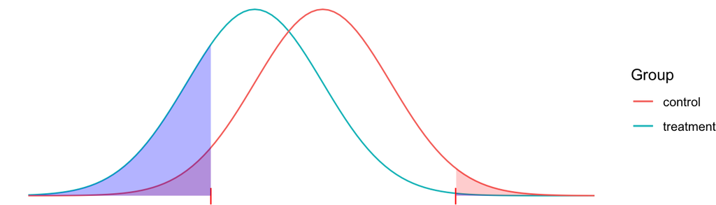

Hình 1.1: *vùng false positive trong 2 nhóm treatment và control của một confounder.*

Dựa vào hình *hình* 1.1, ta thấy rằng phần tô màu đỏ là vùng false positive trong phân bố của một biến confounder thuộc nhóm control. Trong vùng này các quan sát thuộc nhóm control phân bố không dày đặc, nên sẽ khó khăn hơn nếu ta tìm kiếm các điểm trong vùng này để match với quan sát nào đó trong nhóm treatment. Tạm gọi đây là vùng “khó,” giờ ta tính xem xác suất vùng khó này theo như phân bố của nhóm treatment có cao không. Nếu cao, nghĩa là số lượng điểm cần được match trong nhóm treatments tập trung vào vùng “khó” của nhóm control, sẽ gây trở ngại hay không thuận lợi trong quá trình matching. Tóm lại, nếu như $\gamma_t^{\alpha}$ càng cao thì quá trình tìm điểm để match càng khó.

Bốn đại lượng vừa được giới thiệu ở trên sẽ cho ta một đánh giá tổng quan khá hiệu quả về sự khác biệt của các biến confounders trong hai nhóm điều trị. Ngoài ra histograms cũng nên được sử dụng để xem xét về độ che phủ từ 2 nhóm điều trị cũng được, tham khảo tại Vemuri (2015).

# 2 Đánh giá sự khác biệt thông qua phân bố của PS

Ở một khía cạnh khác PS có thể xem là là phương pháp để giảmchiều không gian của data, vì thế mọi sự khác biệt liên quan tới kỳ vọng, phương sai của các covariates giữa hai nhóm điều trị đều sẽ dẫn đến sự khác biệt trong phân bố của PS. Do đó, hoàn toàn hợp lý để đánh giá độ khác biệt của hai nhóm điều trị thông qua phân bố của PS. Đặc biệt sử dụng PS để đánh giá sẽ dễ dàng hơn vì ta chỉ dựa trên 1 chiều không gian đó là vector của PS trong khi đánh giá từng covariates sẽ trở nên khá phức tạp nếu data có chiều không gian lớn.

Giả sử ta kí hiệu PS là $e(x)$ và $\lambda(e)$ chính là một hàm số linearized của PS được định nghĩa như sau

$$\lambda(x) = \ln\frac{e(x)}{1-e(x)}.
\tag{1.7}$$

**proof.** *(yes, you can ignore!!!)*

$$\begin{split}
e(x) - p &= \frac{f_t(x)p}{f_t(x)p + f_c(x)(1-p)} - p \\
&= \frac{f_t(x) - f_c(x)}{f_t(x)p + f_c(x)(1-p)}p(1-p)
\end{split}$$
vì thế
$$\begin{split}
\Bbb{V}[e(x)] &= \Bbb{E}\big[e(x) - \Bbb{E}[e(x)]\big]^2 \\
&= \Bbb{E}\big[e(x) - p\big]^2 \\
&= \Bbb{E}\Big[\Big(\frac{f_t(X_i) - f_c(X_i)}{f_t(X_i)p + f_c(X_i)(1-p)}\Big)^2\Big]p^2(1-p)^2
\end{split}$$

Ta cũng có
$$\begin{split}
\Bbb{E}[e(x)|T=1] &= \int ef_t(e)de = \int \frac{e^2f(x)}{p}dx = \frac{\Bbb{E}[e(x)^2]}{p} = \frac{\Bbb{V}(e(x))+p^2}{p} \\
&=\frac{\Bbb{V}[e(x)]}{p} + p,
\end{split}$$
tương tự ta cũng sẽ có
$$\Bbb{E}[e(x)|T=0] = p - \frac{\Bbb{V}[e(x)]}{1-p}$$
Vì thế ta có
$$\Bbb{E}[e(x)|T=1] - \Bbb{E}[e(x)|T=0] = \frac{\Bbb{V}[e(x)]}{p(1-p)}$$

# 3 Đánh giá khả năng matching

Ta sẽ dựa vào PS để tính hai đại lượng nhằm đánh giá khả năng matching của các units từ hai nhóm điều trị. Cho mỗi một đơn vị $i$ thuộc nhóm điều trị $T=t$ ta sẽ tìm xem có bao nhiêu units $j$ thuộc nhóm đối xứng $T= 1-t$ sao cho

$$l(X_i) - l(X_j) \le \kappa,
\tag{3.1}$$
trong đó giá trị của $\kappa$ thường được chọn là $0.1$, cho biết rằng độ khác biệt trong PS cao nhất là $10%$. Như vậy nếu như càng nhiều unit $j$ thỏa mãn *phương trình* (3.1) thì khả năng matching càng cao.

Ta lấy $\xi_i$ là một hàm chỉ thị nếu như có ít nhất một đơn vị $j$ thỏa mãn *phương trình* (3.1) cho đơn vị $i$. Ta có

$$\xi_i = \cases{1,~~~~~\textit{if}~~~\sum_{j:T_j \ne T_i}{\large\unicode{x1D7D9}}[l(X_j) - l(X_i) \le\kappa] >0 \\
0,~~~~~\textit{otherwise}
}$$

Cuối cùng ta tính trung bình của 2 nhóm điều trị

$$\overline{\xi}^{(c)} = \frac{\sum_{i:T_i=0}\xi_i}{N_c}; ~~~\textit{ và }~~ \overline{\xi}^{(t)} = \frac{\sum_{i:T_i=1}\xi_i}{N_t}$$

# 📝 *References*

Vemuri, V. K. (2015). Causal inference for statistics, social, and biomedical sciences: An introduction by guido w. Imbens and donald b. rubin. *Journal of Information Technology Case and Application Research*, *17*(3-4), 175–179.

[^1]: anh.stats@gmail.com